# Liver Cancer Forecast

## Model 1 - auto.arima

The first model auto.arima will present us with the best model with the lowest AIC.

```r
# set seasonal = FALSE since there's no seasonal signals in our data series
autoarima.Model1 <- auto.arima(trainL.ts, ic = "aic", trace = TRUE, seasonal = FALSE, stepwise = FALSE)
```

```
##
##  ARIMA(0,0,0)            with zero mean     : 1038.405
##  ARIMA(0,0,0)            with non-zero mean : 933.8726
##  ARIMA(0,0,1)            with zero mean     : 1012.902
##  ARIMA(0,0,1)            with non-zero mean : 935.7065
##  ARIMA(0,0,2)            with zero mean     : 997.1395
##  ARIMA(0,0,2)            with non-zero mean : 937.6647
##  ARIMA(0,0,3)            with zero mean     : 991.0892
##  ARIMA(0,0,3)            with non-zero mean : 939.0451
##  ARIMA(0,0,4)            with zero mean     : 988.1105
##  ARIMA(0,0,4)            with non-zero mean : 940.1819
##  ARIMA(0,0,5)            with zero mean     : 984.7808
##  ARIMA(0,0,5)            with non-zero mean : 942.1556
##  ARIMA(1,0,0)            with zero mean     : 983.6068
##  ARIMA(1,0,0)            with non-zero mean : 935.6991
##  ARIMA(1,0,1)            with zero mean     : Inf
##  ARIMA(1,0,1)            with non-zero mean : 937.6131
##  ARIMA(1,0,2)            with zero mean     : Inf
##  ARIMA(1,0,2)            with non-zero mean : 939.5918
##  ARIMA(1,0,3)            with zero mean     : Inf
##  ARIMA(1,0,3)            with non-zero mean : 940.2665
##  ARIMA(1,0,4)            with zero mean     : Inf
##  ARIMA(1,0,4)            with non-zero mean : 942.1234
##  ARIMA(2,0,0)            with zero mean     : 966.9016
##  ARIMA(2,0,0)            with non-zero mean : 937.6491
##  ARIMA(2,0,1) with zero mean     : Inf
##  ARIMA(2,0,1)            with non-zero mean : 939.5988
##  ARIMA(2,0,2)            with zero mean     : Inf
##  ARIMA(2,0,2)            with non-zero mean : Inf
##  ARIMA(2,0,3)            with zero mean     : Inf
##  ARIMA(2,0,3)            with non-zero mean : 938.3046
##  ARIMA(3,0,0)            with zero mean     : 963.7751
##  ARIMA(3,0,0)            with non-zero mean : 939.2568
##  ARIMA(3,0,1)            with zero mean     : Inf
##  ARIMA(3,0,1)            with non-zero mean : 940.2337
##  ARIMA(3,0,2) with zero mean     : Inf
##  ARIMA(3,0,2)            with non-zero mean : Inf
##  ARIMA(4,0,0)            with zero mean     : 963.1107
##  ARIMA(4,0,0)            with non-zero mean : 940.2656
##  ARIMA(4,0,1)            with zero mean     : Inf
##  ARIMA(4,0,1)            with non-zero mean : 941.9804
##  ARIMA(5,0,0)            with zero mean     : 961.5915
##  ARIMA(5,0,0)            with non-zero mean : 942.1781
##
##
##
##  Best model: ARIMA(0,0,0)            with non-zero mean
```

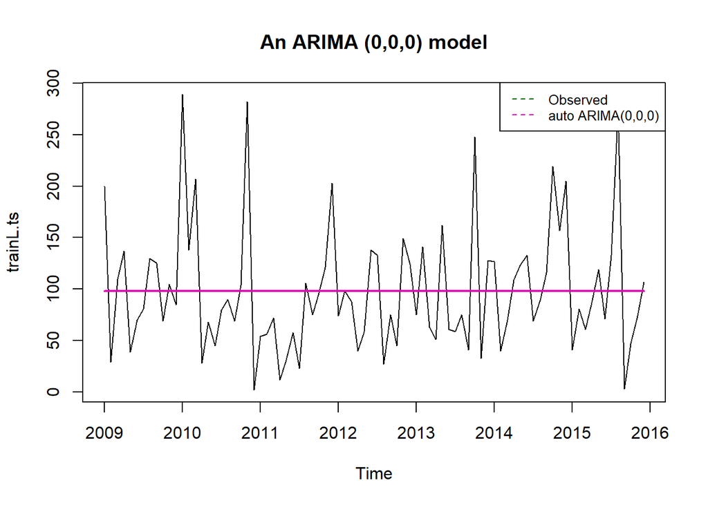

```r
plot(trainL.ts, main = "An ARIMA (0,0,0) model")
lines(fitted(autoarima.Model1), col = "#dc0ab4", lwd = 2)
legend("topright", c("Observed", "auto ARIMA(0,0,0)"), lty = 8, col = c("darkgreen", "#dc0ab4"), cex = 0.8)
```

An ARIMA(0,0,0) model is pretty flat. Let’s check its coefficients:

```r
summary(autoarima.Model1)
```

```
## Series: trainL.ts
## ARIMA(0,0,0) with non-zero mean
##
## Coefficients:
##        mean
##       98.00
## s.e.   6.69
##
## sigma^2 = 3805:  log likelihood = -464.94
## AIC=933.87   AICc=934.02   BIC=938.73
##
## Training set error measures:
##                        ME     RMSE      MAE       MPE     MAPE      MASE
## Training set 1.353617e-14 61.31457 46.92857 -136.1746 161.4497 0.7166187
##                     ACF1
## Training set -0.04492774
```

Examine model 1 residuals

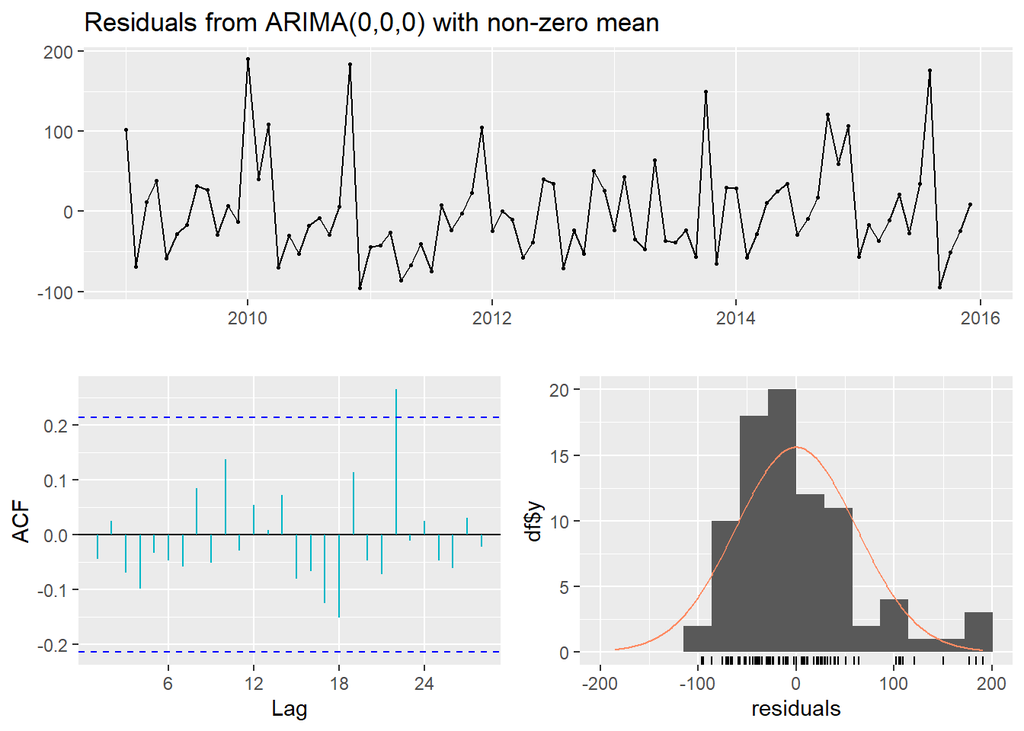

```
##
##  Ljung-Box test
##
## data:  Residuals from ARIMA(0,0,0) with non-zero mean
## Q* = 8.6454, df = 17, p-value = 0.9507
##
## Model df: 0.   Total lags used: 17
```

```r
forecast::checkresiduals(autoarima.Model1, col = "#00B7C7")
```

**Observed graph:** The first graph shows the residuals of the observed data series.\

**ACF plot:** The residuals of our first (auto.arima) model are not that autocorrelated which is good. There’s only one peak, a lag on time step 22, that goes beyond the 95% limits of ACF values. We’ll address the lag on the next model. Note that autocorrelation refers to a problem in data collected repeatedly over time.\

**Residual histogram:** The residuals doesn’t quite follow a normal distribution, it has a couple of bins with very high concentration of cases and other low bins which distort the normal distribution.\

Initialize the forecast term to 60 months (5 years), forecast Model 1, and plot it.

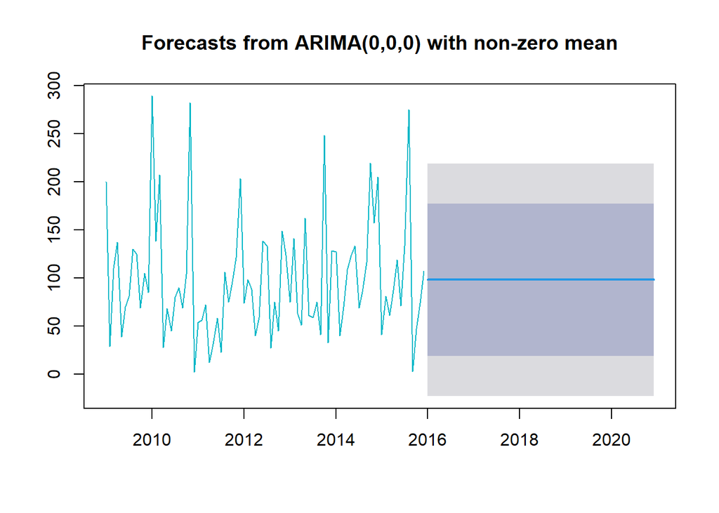

```r
# h is the forecast horizon value, set it to the defined term; otherwise it defaults to 2 years forecast.
autoarima.Model1.Fcast <- forecast(autoarima.Model1, h = term)
plot(autoarima.Model1.Fcast, col = "#00B7C7")
```

The plot shows observed and forecast data series, the prediction is just a flat line at

```r
fcast.mean <- autoarima.Model1.Fcast$mean[1:1]
formattable(fcast.mean, digits = 2, format = "f")
```

```
## [1] 98.00
```

It’s a worthy to note about these two terms:\ fcast$fitted is the result of the fit (the model fitted to observation)\

fcast$mean is the result of the forecast (the application of the model to the future).\

These two terms have a different length for a given h.

Check how well Model 1 forecast

```r
# Check how accurate the forecast is
autoarima.Model1.Fcast.em <- forecast(autoarima.Model1, h = term) %>%
  accuracy(validL.ts)

# Evaluate TS forecast with regression evaluation metrics:
round(autoarima.Model1.Fcast.em[, c("RMSE", "MAPE")], 2)
```

```
##               RMSE   MAPE
## Training set 61.31 161.45
## Test set     60.54 301.40
```

Examine Model 1 coefficients

```
## Series: trainL.ts
## ARIMA(0,0,0) with non-zero mean
##
## Coefficients:
##        mean
##       98.00
## s.e.   6.69
##
## sigma^2 = 3805:  log likelihood = -464.94
## AIC=933.87   AICc=934.02   BIC=938.73
##
## Training set error measures:
##                        ME     RMSE      MAE       MPE     MAPE      MASE
## Training set 1.353617e-14 61.31457 46.92857 -136.1746 161.4497 0.7166187
##                     ACF1
## Training set -0.04492774
```

Akaike information criteria (AIC) is a mathematical method for evaluating how well a model fits the data it was generated from.\ AIC shows us how good a model is relative to the other models.\ Root mean square error (RMSE) tells us how many units our model is wrong on average.\ Mean absolute percentage error (MAPE) tells us how wrong our forecasts are percentage-wise.\ The lower the AIC/RMSE the better the model, likewise, the lower the MAPE the more accurate the forecast is. \

We’ll keep track of AIC and RMSE and store them in an error measure (em) table for comparison with other models as we progressively fit.

```r
# Format the coefficient into an integer
model1.AIC <- formattable(stats::AIC(autoarima.Model1), digits = 1, format = "f")
model1.RMSE <- formattable(autoarima.Model1.Fcast.em[1, c("RMSE")], digits = 1, format = "f")

# rm(em_results)
em_results <- tibble(
  Method = "Model 1 - auto.arima ARIMA(0,0,0)",
  AIC = model1.AIC,
  RMSE = model1.RMSE
)
em_results %>%
  kbl(caption = "Models Performance Table") %>%
  kable_classic_2(full_width = F, c("striped", "hover"))
```

Models Performance Table

| Method | AIC | RMSE |
| --- | --- | --- |
| Model 1 - auto.arima ARIMA(0,0,0) | 933.9 | 61.3 |

## Model 2 - ARIMA(0,0,1)

Previously in the ACF plot on figure ** Residuals from ARIMA(0,0,0) ** shows a spike at lag 22 but no other significant spikes; this suggests that the model may better with a different specification, such as p=22 or q=22.

ARIMA can be identified as the order of AR, I, MA terms. An ARIMA model has three component functions: The order of the non-seasonal auto-regressive (AR) terms. If p = NULL, an optimal number of lags will be selected for a linear AR(p) model via AIC. I(d)is the difference in the nonseasonal observations; and MA(q) is the size of the moving average window.

ARIMA(0,0,22) was fitted and evaluated; There was a noticeably huge difference in the RMSE between the the two data sets. The model may had been overfitted.

[output not shown]

Training set 50.04900 97.7645 Test set 60.65764 289.0207

The model was modified from ARIMA(0,0,22) to ARIMA(0,0,1).

For the second model, we identify AR = 0, I=0, and MA=1 or simply called it an ARIMA model for a first order of MA process. We can repeat the fitting process allowing for the MA(1) component and examine diagnostic and plot.

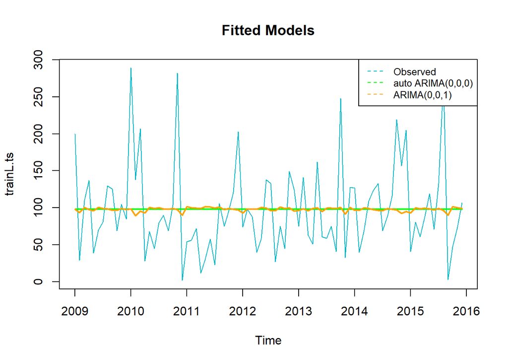

```r
MA1.model2 <- forecast::Arima(trainL.ts, c(0, 0, 1))
plot(trainL.ts, col = "#00B7C7", main = "Fitted Models")
lines(fitted(autoarima.Model1), col = "green", lwd = 2)
lines(fitted(MA1.model2), col = "#ffa300", lwd = 2)
legend("topright", c("Observed", "auto ARIMA(0,0,0)", "ARIMA(0,0,1)"), lty = 8, col = c("#00B7C7", "green", "#FFA300"), cex = 0.8)
```

Visually Model 1 and 2 look very similar. Let’s explore how model 2 is fitting.

```
## Series: trainL.ts
## ARIMA(0,0,1) with non-zero mean
##
## Coefficients:
##           ma1     mean
##       -0.0441  97.9440
## s.e.   0.1083   6.3936
##
## sigma^2 = 3843:  log likelihood = -464.85
## AIC=935.71   AICc=936.01   BIC=943
##
## Training set error measures:
##                      ME     RMSE      MAE       MPE     MAPE      MASE
## Training set 0.05296268 61.25327 46.99669 -128.2694 153.5474 0.7176589
##                      ACF1
## Training set 2.937896e-05
```

Model 2 residuals plots

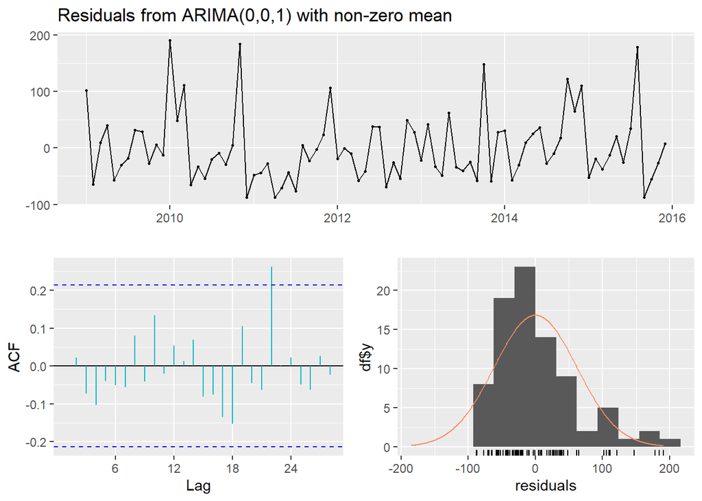

```
##
##  Ljung-Box test
##
## data:  Residuals from ARIMA(0,0,1) with non-zero mean
## Q* = 8.7871, df = 16, p-value = 0.9219
##
## Model df: 1.   Total lags used: 17
```

```r
forecast::checkresiduals(MA1.model2, col = "#00B7C7")
```

**Observed graph:** The residuals of the observed data. **ACF plot:** There is a spike at time step 22 and everything else seems to be within acceptable range.  
**Residual histogram:** The residuals still doesn’t follow a normal distribution, it has a couple of bins with very high concentration of live cancer cases then cascade down to the other lower bins on the right which distort the normal distribution.

Forecast from Model 2

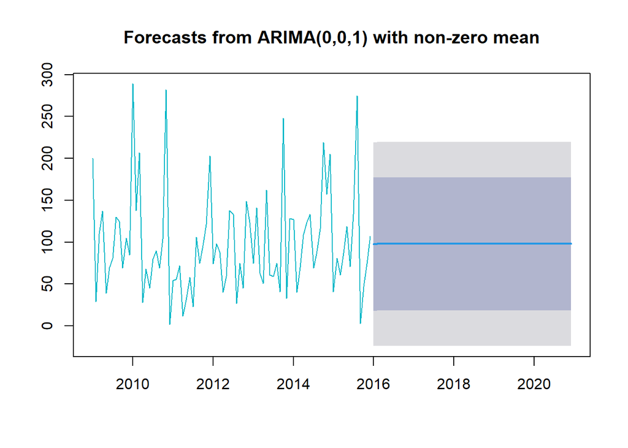

```r
MA1.model2.Fcast <- forecast(MA1.model2, h = term)
plot(MA1.model2.Fcast, col = "#00B7C7")
```

Model 2 forecast shows a flat lined prediction at

```
## [1] 97.6
```

Check how well Model 2 forecast

```r
# Evaluate TS forecast with regression evaluation metrics:
# Check how accurate the forecast is
MA1.model2.Fcast.em <- forecast(MA1.model2, h = term) %>%
  accuracy(validL.ts)

# Check TS forecast accuracy with regression evaluation metrics:
MA1.model2.Fcast.em[, c("RMSE", "MAPE")]
```

```
##                  RMSE     MAPE
## Training set 61.25327 153.5474
## Test set     60.52440 301.1880
```

Record our findings.

Models Performance Table

| Method | AIC | RMSE |
| --- | --- | --- |
| Model 1 - auto.arima ARIMA(0,0,0) | 933.9 | 61.3 |
| Model 2 - ARIMA(0,0,1) | 935.7 | 61.3 |

AIC measures how well the model will fit new data, not the existing data. Lower AIC means that a model should have improved prediction. Frequently adding more variables decreases predictive accuracy and in that case the model with higher RMSE will have a higher (worse) AIC.

The AIC quantifies the goodness of fit and simplicity of the model into a single statistic. When comparing two models, the one with the lower AIC is considered to be better; however, the RMSE is a frequently used measure of the differences between values predicted by a model or an estimator and the values observed. The lower the RMSE the better when calculating the accuracy of predictions of a model. (Tracyenee 2022)

Even though both AIC and RMSE are being tracked, the model with the lowest RMSE will be selected due to the objective of this project, accurate forecasting.

## Model 3 - ARIMA(0,0,0) with Fourier Term

Using an ARIMA model alone does not sufficiently capture the long-term patterns, the Fourier term is introduced into the model.  
[Ludlow & Enders (2000, IJF)](https://stats.stackexchange.com/questions/215865/fourier-terms-to-model-seasonality-in-arima-models)

K - every periodic function can be approximated by sums of sin and cos terms for large enough K. The best way to select K is to try a few different values and select the model that gives the lowest AIC values. Choose K to minimize the AIC start with K =1 and slowly increase it until the AICs value stops decreasing.

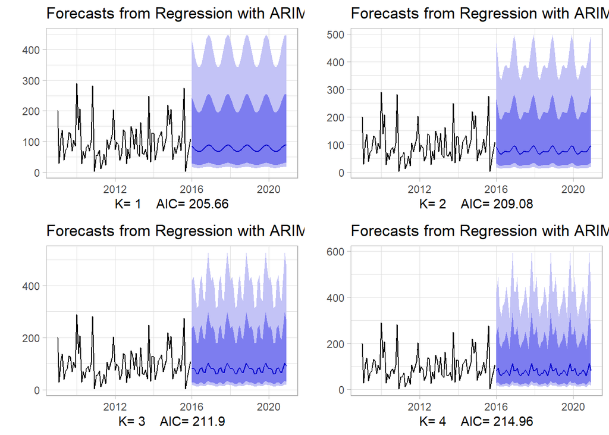

```r
############################################
# Model 3
# Approaches to TS data with weak seasonality.
###########################################
# Comparing with plots
plots <- list()
for (i in seq(4)) {
  fit <- trainL.ts %>%
    auto.arima(xreg = fourier(trainL.ts, K = i), seasonal = FALSE, lambda = "auto")
  plots[[i]] <- autoplot(forecast(fit, xreg = fourier(trainL.ts, K = i, h = term))) +
    xlab(paste("K=", i, "   AIC=", round(fit[["aic"]], 2))) +
    ylab("") +
    theme_light()
}

gridExtra::grid.arrange(
  plots[[1]], plots[[2]],
  plots[[3]], plots[[4]],
  nrow = 2
)
```

It seems K=1 has the lowest AIC value. Fit model 3 with K=1 and plot it with the other fitted models.

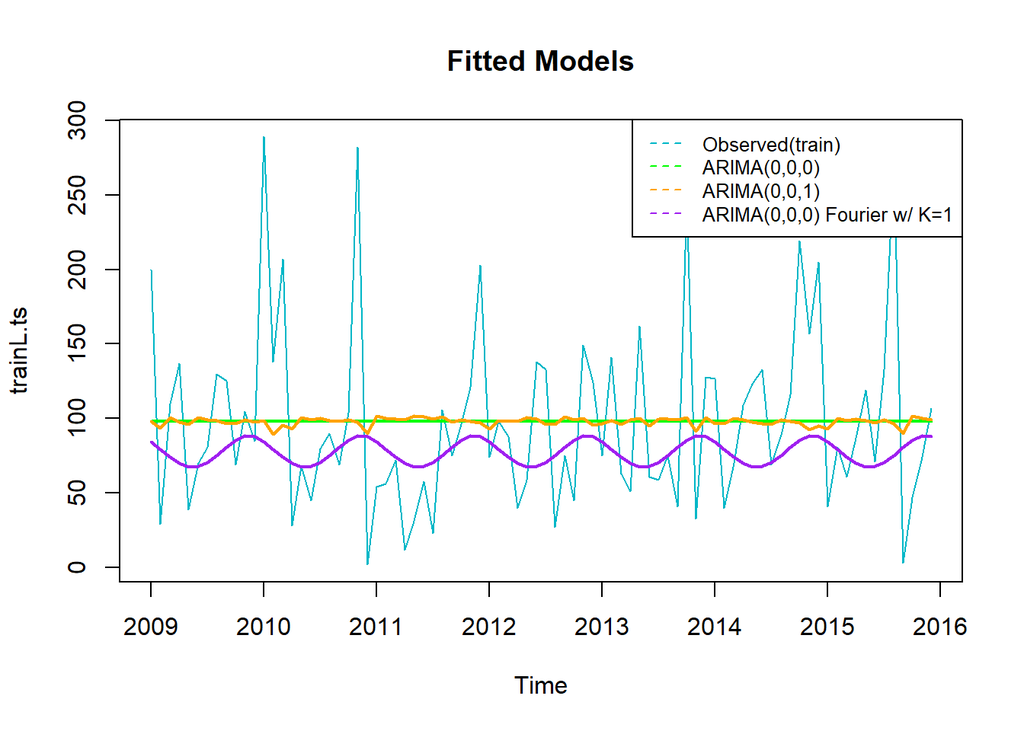

```r
# Modeling with Fourier Regression
fit.fourier.model3 <- trainL.ts %>%
  auto.arima(xreg = fourier(trainL.ts, K = 1), seasonal = FALSE, lambda = "auto")

# Plot fitted models
plot(trainL.ts, col = "#00B7C7", main = "Fitted Models")
lines(fitted(autoarima.Model1), col = "green", lwd = 2)
lines(fitted(MA1.model2), col = "#ffa300", lwd = 2)
lines(fitted(fit.fourier.model3), col = "purple", lwd = 2)
legend("topright", c("Observed(train)", "ARIMA(0,0,0)", "ARIMA(0,0,1)", "ARIMA(0,0,0) Fourier w/ K=1"), lty = 8, col = c("#00B7C7", "green", "#FFA300", "purple"), cex = 0.8)
```

```r
summary(fit.fourier.model3)
```

```
## Series: .
## Regression with ARIMA(0,0,0) errors
## Box Cox transformation: lambda= -0.006889242
##
## Coefficients:
##       intercept    S1-12   C1-12
##          4.2826  -0.0410  0.1255
## s.e.     0.0856   0.1211  0.1211
##
## sigma^2 = 0.6386:  log likelihood = -98.83
## AIC=205.66   AICc=206.17   BIC=215.38
##
## Training set error measures:
##                    ME     RMSE      MAE       MPE     MAPE      MASE
## Training set 20.38854 63.18001 44.25446 -92.12438 131.2875 0.6757839
##                     ACF1
## Training set -0.08790084
```

Noticeably drop of Model 3 AIC value

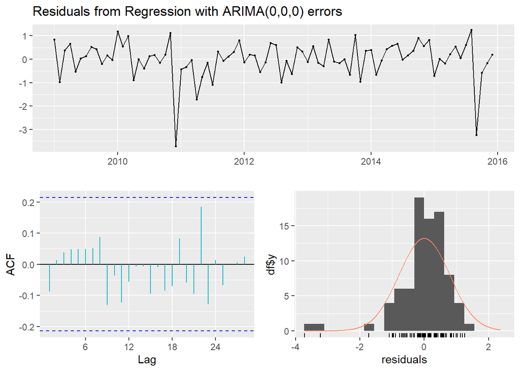

```
##
##  Ljung-Box test
##
## data:  Residuals from Regression with ARIMA(0,0,0) errors
## Q* = 7.7345, df = 17, p-value = 0.9719
##
## Model df: 0.   Total lags used: 17
```

```r
forecast::checkresiduals(fit.fourier.model3, col = "#00B7C7")
```

**ACF plot:** The residuals of Model 3 seem to be within acceptable range.  
**Residual histogram:** The residuals doesn’t quite follow a normal distribution, it has bins with very high concentration of cases then a couple of trail off lower bins on the left which again distort the normal distribution.

Check how well our 3rd fitted model fair between training and test set (Validation).

```
##              RMSE  MAPE
## Training set 63.2 131.3
## Test set     63.0 244.4
```

The results look very compatible between the two data sets. Plot Model 3 Fourier Regression forecast

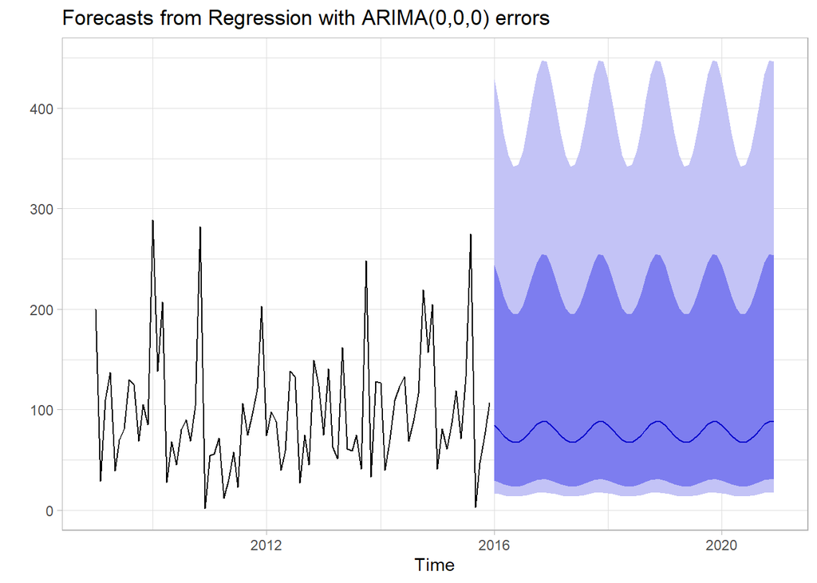

```r
# Plot of the Fourier Regression Model 3 forecast, train.ts fit and valid.ts
fit.fourier.model3.fcast <- forecast(fit.fourier.model3, xreg = fourier(trainL.ts, K = 1, h = term))

autoplot(fit.fourier.model3.fcast) +
  theme_light() +
  ylab("")
```

Our data don’t have any trend or seasonality; however this forecast and predicted data (below) seems to tell a different story.

```
##       Jan  Feb  Mar  Apr  May  Jun  Jul  Aug  Sep  Oct  Nov  Dec
## 2016 84.6 79.5 74.1 69.8 67.6 67.9 70.5 75.1 80.6 85.5 88.3 87.9
## 2017 84.6 79.5 74.1 69.8 67.6 67.9 70.5 75.1 80.6 85.5 88.3 87.9
## 2018 84.6 79.5 74.1 69.8 67.6 67.9 70.5 75.1 80.6 85.5 88.3 87.9
## 2019 84.6 79.5 74.1 69.8 67.6 67.9 70.5 75.1 80.6 85.5 88.3 87.9
## 2020 84.6 79.5 74.1 69.8 67.6 67.9 70.5 75.1 80.6 85.5 88.3 87.9
```

Record Model 3 performance

Models Performance Table

| Method | AIC | RMSE |
| --- | --- | --- |
| Model 1 - auto.arima ARIMA(0,0,0) | 933.9 | 61.3 |
| Model 2 - ARIMA(0,0,1) | 935.7 | 61.3 |
| Model 3 - ARIMA(0,0,0) with Fourier K=1 | 205.7 | 63.2 |

Based on AIC value, Model 3 seems to lead.

## Model 4 - ARIMA(0,0,0) with Transformed Data

Setting approximation = FALSE makes auto.arima work harder to find the right solution. Box Cox transformations help determine what is the best way to transform your data based on the lambda. Lambda here is used to represent the number that will be used to select the optimal transformation for the data. The optimal transformation of the data is that transformation that makes the data approximate the most to a normal distribution.

These two other methods allow for constants to be added to the model and for more complex models to be considered.  
Drift: Only available when the differencing is above 0 and allows models with a changing average to be fit.  
Mean: Allows models with a non-zero mean to be considered.

By default, R sets them as TRUE, again opting for speed over performance. Setting these parameters to FALSE allows the model to work harder, but watch out for overfitting. (Losada 2020)

```r
fit.arima.trans.model4 <- trainL.ts %>%
  auto.arima(stepwise = FALSE, approximation = FALSE, lambda = "auto")
fit.arima.trans.model4
```

```
## Series: .
## ARIMA(0,0,0) with non-zero mean
## Box Cox transformation: lambda= -0.006889242
##
## Coefficients:
##         mean
##       4.2826
## s.e.  0.0862
##
## sigma^2 = 0.6321:  log likelihood = -99.42
## AIC=202.84   AICc=202.99   BIC=207.7
```

As seen above code chunk, stepwise=FALSE, approximation=FALSE parameters are used to amplify the searching for all possible model options. We set lambda parameter to “auto”. It makers the data transformed with lambda= -0.007.

From the results above ARIMAR(0,0,0) which can be denoted as ARIMA(p,d,q) we can see that there is no autoregressive (AR) part of the model, order moving average (MA), or differencing (I).

Based on the AIC, this model seems to fitted better than the previous models.

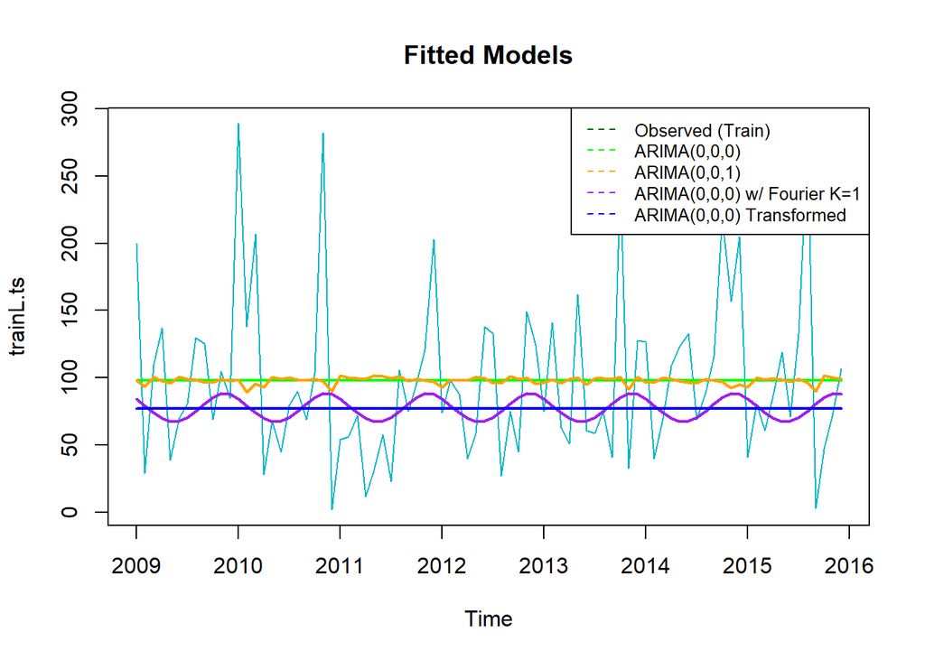

```
## Series: .
## ARIMA(0,0,0) with non-zero mean
## Box Cox transformation: lambda= -0.006889242
##
## Coefficients:
##         mean
##       4.2826
## s.e.  0.0862
##
## sigma^2 = 0.6321:  log likelihood = -99.42
## AIC=202.84   AICc=202.99   BIC=207.7
##
## Training set error measures:
##                    ME     RMSE      MAE     MPE     MAPE      MASE        ACF1
## Training set 20.74885 64.73014 45.41661 -86.171 125.9319 0.6935304 -0.04492774
```

```r
# Plot fitted models
plot(trainL.ts, col = "#00B7C7", main = "Fitted Models")
lines(fitted(autoarima.Model1), col = "green", lwd = 2)
lines(fitted(MA1.model2), col = "#ffa300", lwd = 2)
lines(fitted(fit.fourier.model3), col = "purple", lwd = 2)
lines(fitted(fit.arima.trans.model4), col = "blue", lwd = 2)
legend("topright", c("Observed (Train)", "ARIMA(0,0,0)", "ARIMA(0,0,1)", "ARIMA(0,0,0) w/ Fourier K=1", "ARIMA(0,0,0) Transformed"), lty = 8, col = c("darkgreen", "green", "#FFA300", "purple", "blue"), cex = 0.8)
```

Look how low the AIC is for Model 4!

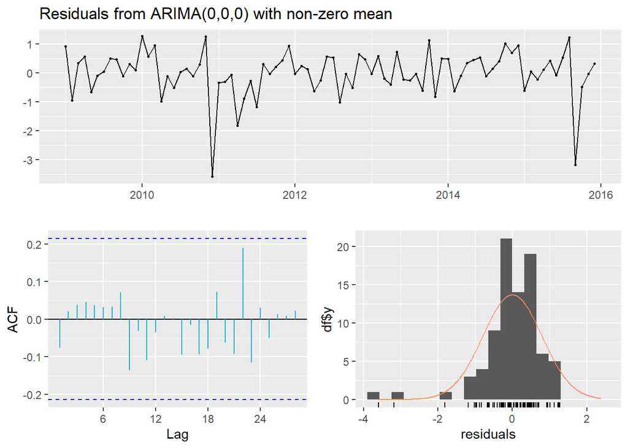

```
##
##  Ljung-Box test
##
## data:  Residuals from ARIMA(0,0,0) with non-zero mean
## Q* = 6.7373, df = 17, p-value = 0.9867
##
## Model df: 0.   Total lags used: 17
```

There is no lag indication in the ACF plot and residual histogram has slightly improved compared to previous model 3.

Forecast on Model 4

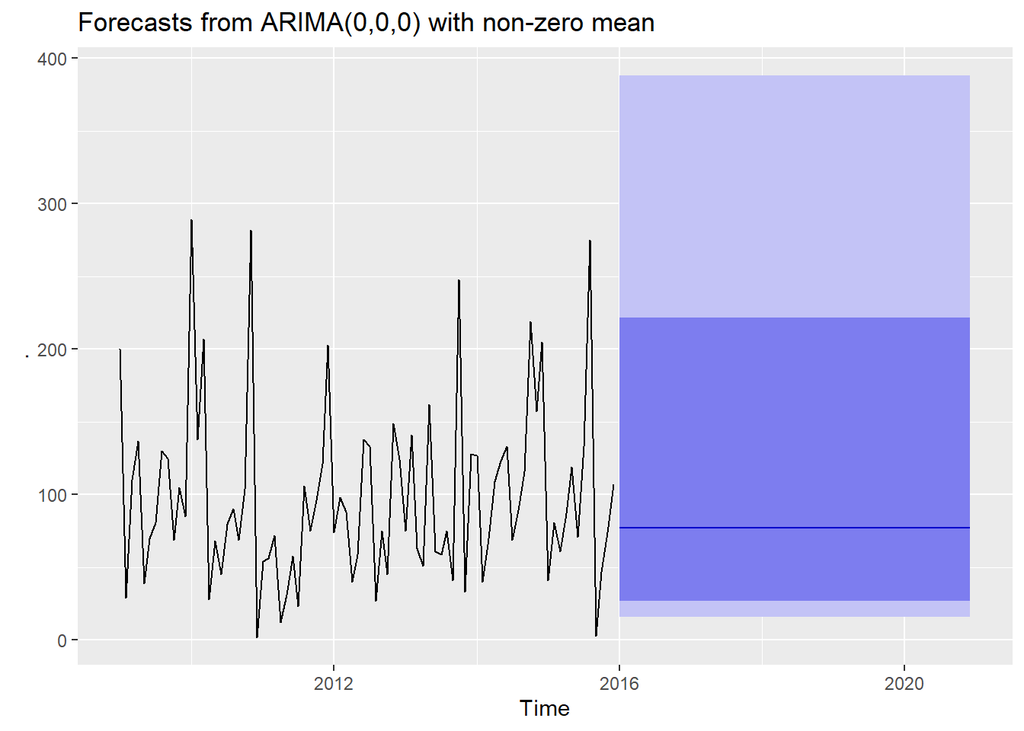

```r
par(mfrow = c(1, 1))
fit.arima.trans.model4.fcast <- forecast(fit.arima.trans.model4, h = term)
autoplot(fit.arima.trans.model4.fcast)
```

With a non-seasonality, it’s not uncommon to have a flat prediction.

```
## [1] 77.3
```

```
##                  RMSE     MAPE
## Training set 64.73014 125.9319
## Test set     61.79506 234.1500
```

Record Model 4 AIC

Models Performance Table

| Method | AIC | RMSE |
| --- | --- | --- |
| Model 1 - auto.arima ARIMA(0,0,0) | 933.9 | 61.3 |
| Model 2 - ARIMA(0,0,1) | 935.7 | 61.3 |
| Model 3 - ARIMA(0,0,0) with Fourier K=1 | 205.7 | 63.2 |
| Model 4 - ARIMA(0,0,0) w/ Transformation | 202.8 | 64.7 |

## Model 5 - Single Exponential Smoothing (SES)

Single Exponential Smoothing (SES) is useful for forecasting a series with no trend and no seasonality. SES forecasts future values using a weighted average of all previous values in the series. Advantages of this method is that it’s simple, popular, and adaptive. The key concepts is smoothing constant. This method, which results in a straight, flat-line forecast is best for volatile data with no trend or seasonality.(GreeksforGeeks 2022)

Start Model 5a with a smaller alpha = 0.01; fit & forecast the model, and examine its coefficients

```r
ses.fit.model5a <- ses(trainL.ts,
  alpha = 0.01,
  h = term
)

ses.fit.model5a.coef <- summary(ses.fit.model5a)
ses.fit.model5a.coef$model
```

```
## Simple exponential smoothing
##
## Call:
##  ses(y = trainL.ts, h = term, alpha = 0.01)
##
##   Smoothing parameters:
##     alpha = 0.01
##
##   Initial states:
##     l = 98.0139
##
##   sigma:  62.3491
##
##      AIC     AICc      BIC
## 1068.466 1068.614 1073.328
```

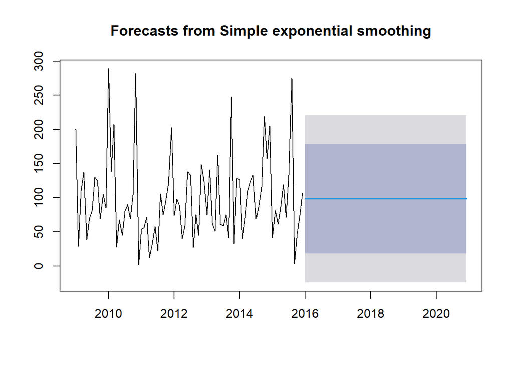

```r
plot(ses.fit.model5a)
```

Model 5 flattens at

```
## [1] 98.3
```

Model 5 accuracy

```
##              RMSE  MAPE
## Training set 61.6 164.2
## Test set     60.6 302.6
```

Compare models based on the lowest alpha

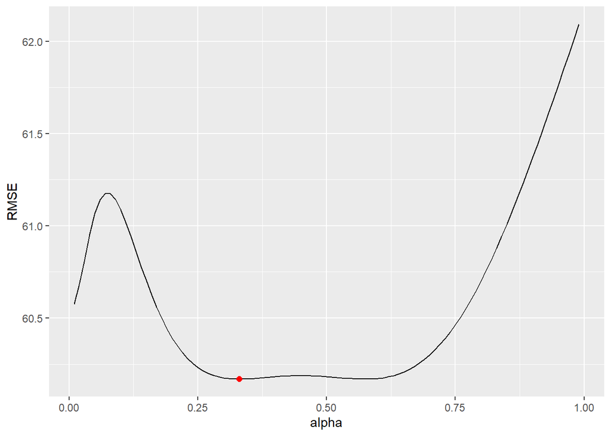

```r
alpha <- seq(.01, .99, by = .01)
RMSE <- NA
for (i in seq_along(alpha)) {
  fit <- ses(trainL.ts,
    alpha = alpha[i],
    h = term
  )

  RMSE[i] <- accuracy(fit, validL.ts)[2, 2]
}

# convert to a data frame and identify min alpha value
alpha.fit <- tibble(alpha, RMSE)
# alpha.fit
alpha.min <- filter(
  alpha.fit,
  RMSE == min(RMSE)
)

ggplot(alpha.fit, aes(alpha, RMSE)) +
  geom_line() +
  geom_point(
    data = alpha.min,
    aes(alpha, RMSE),
    lwd = 2, color = "red"
  )
```

```r
alpha.min
```

```
## # A tibble: 1 × 2
##   alpha  RMSE
##   <dbl> <dbl>
## 1  0.33  60.2
```

Now, we will try to re-fit our forecast model for SES with alpha = 0.33. We will notice the significant difference between alpha 0.01 and alpha=0.33.

```r
ses.fit.model5b <- ses(trainL.ts,
  alpha = 0.33,
  h = term
)

ses.fit.model5b.coef <- summary(ses.fit.model5b)
ses.fit.model5b.coef$model
```

```
## Simple exponential smoothing
##
## Call:
##  ses(y = trainL.ts, h = term, alpha = 0.33)
##
##   Smoothing parameters:
##     alpha = 0.33
##
##   Initial states:
##     l = 117.7172
##
##   sigma:  68.9569
##
##      AIC     AICc      BIC
## 1085.389 1085.538 1090.251
```

Check model5b forecast accuracy

```
##                  RMSE     MAPE
## Training set 68.13105 221.8442
## Test set     60.16912 279.1185
```

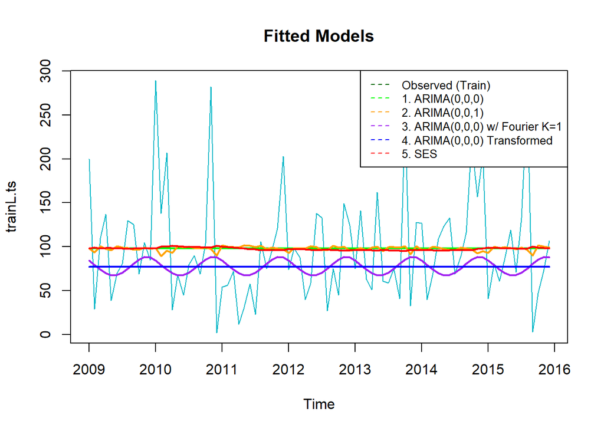

```r
plot(trainL.ts, col = "#00B7C7", main = "Fitted Models")
lines(fitted(autoarima.Model1), col = "green", lwd = 2)
lines(fitted(MA1.model2), col = "#ffa300", lwd = 2)
lines(fitted(fit.fourier.model3), col = "purple", lwd = 2)
lines(fitted(fit.arima.trans.model4), col = "blue", lwd = 2)
lines(fitted(ses.fit.model5a), col = "red", lwd = 2)
legend("topright", c("Observed (Train)", "1. ARIMA(0,0,0)", "2. ARIMA(0,0,1)", "3. ARIMA(0,0,0) w/ Fourier K=1", "4. ARIMA(0,0,0) Transformed", "5. SES"), lty = 8, col = c("darkgreen", "green", "#FFA300", "purple", "blue", "red"), cex = 0.8)
```

Visually Model 1, 2, and 5 look closely similar.  
Model 4 seems to be the average line running through Model 3.

Plot model 5 forecast

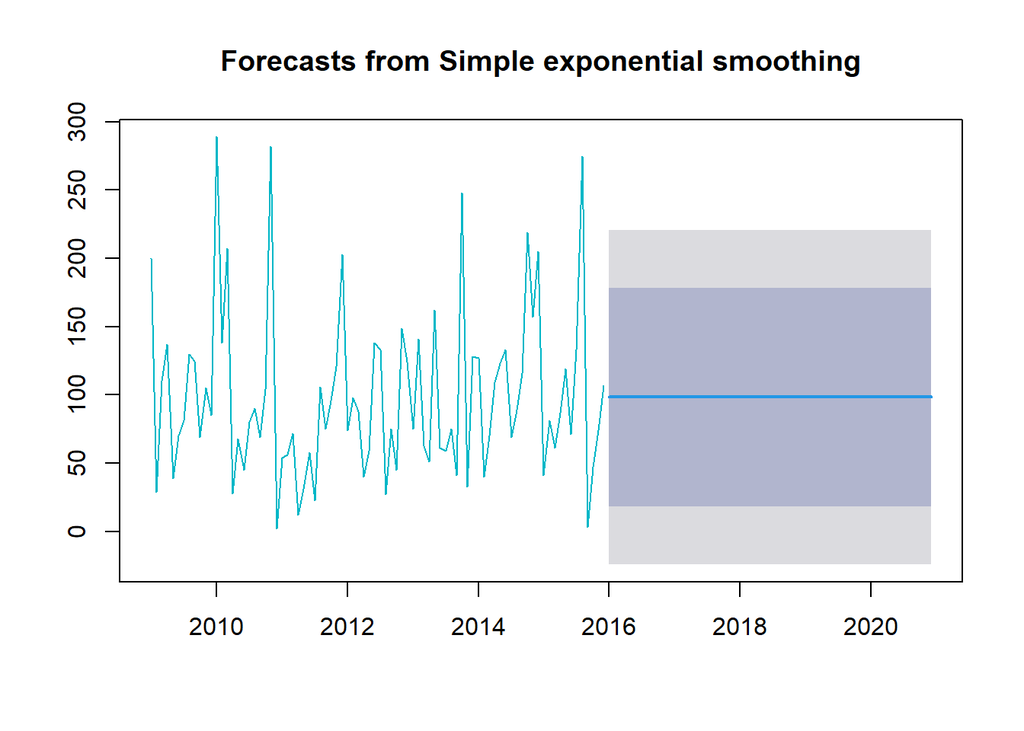

```r
plot(ses.fit.model5a, col = "#00B7C7")
```

Flat Prediction at

```
## [1] 98.3
```

Examine Model 5 AIC

```r
ses.fit.model5a.coef <- summary(ses.fit.model5a)
ses.fit.model5a.coef$model
```

```
## Simple exponential smoothing
##
## Call:
##  ses(y = trainL.ts, h = term, alpha = 0.01)
##
##   Smoothing parameters:
##     alpha = 0.01
##
##   Initial states:
##     l = 98.0139
##
##   sigma:  62.3491
##
##      AIC     AICc      BIC
## 1068.466 1068.614 1073.328
```

Based on the AIC and RMSE, Model5a is better than Model5b. Record model5a’s performance as Model 5’s

Models Performance Table

[output not shown]

Notice how high AIC value is for model 5. It might not be a good idea to compare Model5’s AIC with other models. Fitted model5 is based on the ses() function which uses means of data while other models whose coefficients have been estimating using maximum likelihood (ML).

It is also worthy to note that observations are lost with differencing or with lagging; therefore, we should not compare the AIC of an ARIMA model with differencing to one without differencing. (Hyndman 2013)

## Model 6 - Neural Netwrok Auto-Regressive Time sEries Forcast

We will fit one more model, Model 6 - NNEtar: Neural Network Auto-Regressive Time Series Forecast.  
NNetar is a feed-forward neural networks with a single hidden layer and lagged inputs for forecasting univariate time series.  
Univariate is a term commonly used in statistics to describe a type of data which consists of observations on only a single characteristic or attribute. A simple example of univariate data would be the annual liver caner number. Neural networks work better at predictive analytics because of the hidden layers. Linear regression models use only input and output nodes to make predictions. The neural network also uses the hidden layer to make predictions more accurate.(Warudkar 2020)

```r
nnetar.fit.Model6 <- nnetar(trainL.ts)
summary(nnetar.fit.Model6)
```

```
##           Length Class        Mode
## x         84     ts           numeric
## m          1     -none-       numeric
## p          1     -none-       numeric
## P          1     -none-       numeric
## scalex     2     -none-       list
## size       1     -none-       numeric
## subset    84     -none-       numeric
## model     20     nnetarmodels list
## nnetargs   0     -none-       list
## fitted    84     ts           numeric
## residuals 84     ts           numeric
## lags       2     -none-       numeric
## series     1     -none-       character
## method     1     -none-       character
## call       2     -none-       call
```

Plot fitted models

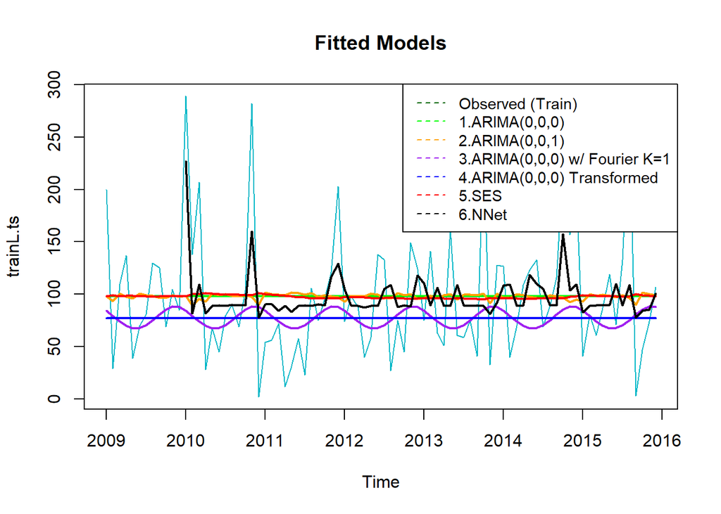

Plot the forecast

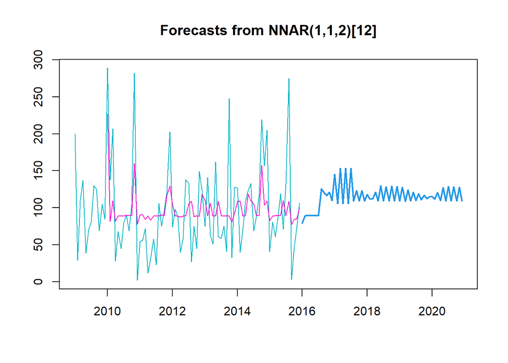

```r
plot(forecast(nnetar.fit.Model6, h = term), col = "#00B7c7")
points(fitted(nnetar.fit.Model6), type = "l", col = "#FF00CC")
```

```r
nnetar.fit.Model6.fcast <- forecast(nnetar.fit.Model6, h = term)
round(nnetar.fit.Model6.fcast$mean, 1)
```

```
##        Jan   Feb   Mar   Apr   May   Jun   Jul   Aug   Sep   Oct   Nov   Dec
## 2016  79.0  89.6  89.6  89.7  89.7  89.7  89.6 125.9 120.8 116.6 121.2 110.1
## 2017 145.0 105.9 153.2 105.8 153.2 105.8 153.2 109.5 123.2 109.4 123.3 109.5
## 2018 118.0 112.0 112.3 120.9 109.5 129.8 109.4 128.2 109.2 129.1 109.2 129.0
## 2019 109.1 128.0 109.1 124.4 109.4 120.9 110.1 119.1 110.9 117.2 112.3 114.8
## 2020 115.0 112.0 120.5 109.7 127.0 109.2 128.7 109.1 128.5 109.1 127.8 109.1
```

Check Model 6 forecast accuracy

```r
nnetar.fit.Model6.fcast.em <- nnetar.fit.Model6 %>%
  forecast(h = term) %>%
  accuracy(validL.ts)

round(nnetar.fit.Model6.fcast.em[, c("RMSE", "MAPE")], 1)
```

```
##              RMSE  MAPE
## Training set 52.6 146.8
## Test set     64.5 348.5
```

It seems a huge prediction difference between training and validation data set. Maybe there is an overfitting issue with this model. Record Model 6 performance.

Models Performance Table

[output not shown]

# 6. Validate the Best Fitted Model

Validate Model 6 against the hold-out-set

```r
nnetar.fit.model.final <- nnetar(validL.ts)
summary(nnetar.fit.model.final)
```

```
##           Length Class        Mode
## x         84     ts           numeric
## m          1     -none-       numeric
## p          1     -none-       numeric
## P          1     -none-       numeric
## scalex     2     -none-       list
## size       1     -none-       numeric
## subset    84     -none-       numeric
## model     20     nnetarmodels list
## nnetargs   0     -none-       list
## fitted    84     ts           numeric
## residuals 84     ts           numeric
## lags       3     -none-       numeric
## series     1     -none-       character
## method     1     -none-       character
## call       2     -none-       call
```

Plot the best fitted model

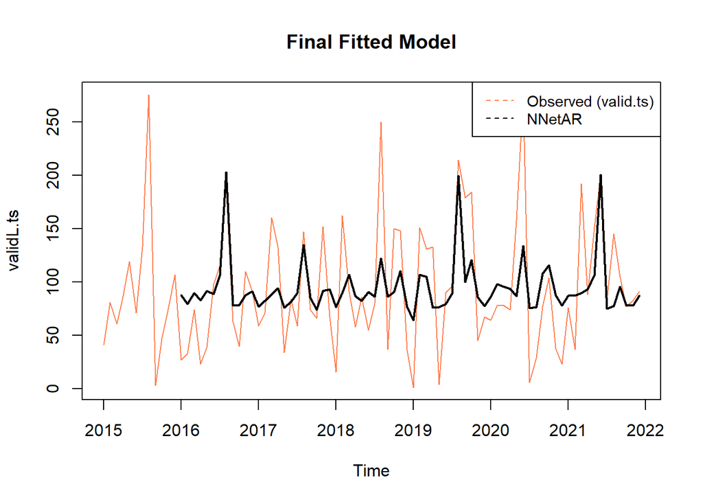

```r
# Plot fitted models
plot(validL.ts, col = "#FF7f50", main = "Final Fitted Model")
lines(fitted(nnetar.fit.model.final), col = "black", lwd = 2)
legend("topright", c("Observed (valid.ts)", "NNetAR"), lty = 8, col = c("#FF7F50", "black"), cex = 0.9)
```

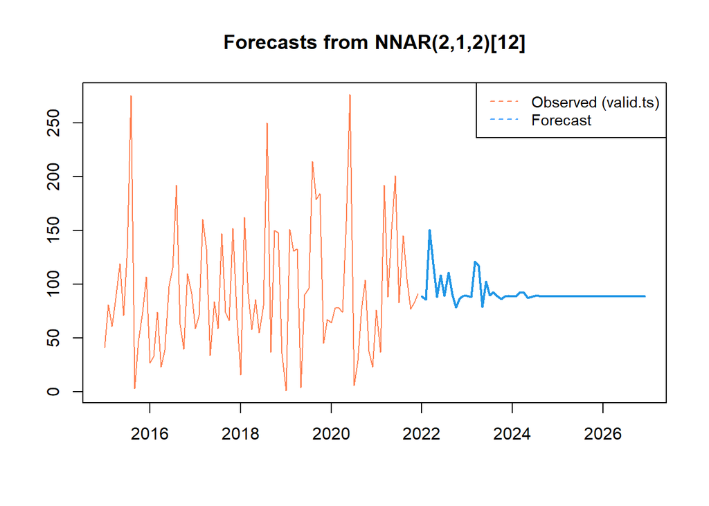

```r
plot(forecast(nnetar.fit.model.final, h = term), col = "#FF7F50")
legend("topright", c("Observed (valid.ts)", "Forecast"), lty = 8, col = c("#FF7F50", "#3399FF"), cex = 0.9)
```

```r
nnetar.fit.model.final.fcast <- forecast(nnetar.fit.model.final, h = term)
round(nnetar.fit.model.final.fcast$mean, 1)
```

```
##        Jan   Feb   Mar   Apr   May   Jun   Jul   Aug   Sep   Oct   Nov   Dec
## 2022  88.7  85.8 150.4 118.3  88.2 108.1  89.2 110.9  90.8  78.5  87.0  89.3
## 2023  89.0  88.4 121.0 117.3  78.8 102.5  89.7  92.8  88.8  86.5  88.5  89.0
## 2024  88.8  88.6  92.4  92.3  87.1  88.0  89.0  89.0  88.7  88.5  88.7  88.8
## 2025  88.7  88.7  88.9  88.9  88.6  88.6  88.7  88.7  88.7  88.7  88.7  88.7
## 2026  88.7  88.7  88.7  88.7  88.7  88.7  88.7  88.7  88.7  88.7  88.7  88.7
```

The neural networks (Nnetar) time series forecasts show a monthly flux trend in the number of liver cancer cases. On a monthly average the maximum and minimum are:

```
## [1] 150.4
```

```
## [1] 78.5
```

Average max and min cases per year

Overview of the forecast values

| fy | avg.max | pct.max.change | avg.min | pct.min.change |
| --- | --- | --- | --- | --- |
| 2022 | 150.4 | NA | 78.5 | NA |
| 2023 | 121.0 | -19.5 | 78.8 | 0.4 |
| 2024 | 92.4 | -23.6 | 87.1 | 10.5 |
| 2025 | 88.9 | -3.8 | 88.6 | 1.7 |
| 2026 | 88.7 | -0.2 | 88.7 | 0.1 |

The Overview of the Forecast Values table shows the fy, average max, percent max change, average min, and percent min change of the liver cancer cases.

```
##  RMSE  MAPE
##  46.3 180.2
```

Record the final model performance and compare.

Models Performance Table

[output not shown]

# 7. Conclusion

Actual Cases 2009-2021 —vs– Forecast Cases 2022-2026

| fy | case_count | avg_count | percent_change |
| --- | --- | --- | --- |
| 2009 | 5267 | 92.4 | NA |
| 2010 | 5524 | 95.2 | 4.9 |
| 2011 | 6026 | 103.9 | 9.1 |
| 2012 | 6809 | 113.5 | 13.0 |
| 2013 | 7223 | 118.4 | 6.1 |
| 2014 | 7948 | 134.7 | 10.0 |
| 2015 | 9124 | 147.2 | 14.8 |
| 2016 | 9023 | 147.9 | -1.1 |
| 2017 | 9443 | 154.8 | 4.7 |
| 2018 | 9821 | 158.4 | 4.0 |
| 2019 | 9549 | 151.6 | -2.8 |
| 2020 | 9908 | 154.8 | 3.8 |
| 2021 | 9297 | 145.3 | -6.2 |

| fy | avg.max | pct.max.change | avg.min | pct.min.change |
| --- | --- | --- | --- | --- |
| 2022 | 150.4 | NA | 78.5 | NA |
| 2023 | 121.0 | -19.5 | 78.8 | 0.4 |
| 2024 | 92.4 | -23.6 | 87.1 | 10.5 |
| 2025 | 88.9 | -3.8 | 88.6 | 1.7 |
| 2026 | 88.7 | -0.2 | 88.7 | 0.1 |

Fitting ARIMA model is more of an art than a science (weecology 2021). In reality, over two dozen models were fitted but only six are presented in this project.

## Additional Work

- We acknowledge that the time frame of this project is a limitation. Specifically, liver cancer data were only available from 2009 to 2021.
- Include Box-Cox Transformation in the model fitting process. Box-Cox method helps to address non-normally distributed data by transforming to normalize the data. When the assumption of data normally distributed is violated or the relationship between the dependent and independent variables in case of linear model are not linear, In such situations some transformations methods that may help the data set follow a normal distribution. It’s worthy to note that a value of λ=0 corresponds to the multiplicative decomposition while λ=1 is equivalent to an additive decomposition. You can use a Box-Cox Transformation by setting lambda = 0 because the variance increases with the level of the series.(Dynamic harmonic regression by datacamp).
- Clean any outliers using tsclean(), if necessary impute any missing values. Time Series data have a continuity and a dependence and having any missing values will affect your model severely.
- Additional data and trend analysis would be helpful including lag.plot,
- Perform decompose() to isolate irregular data and seasonal, if there are seasonal signals in the data.
- Future work could examine how the time trends could change according to specific demographic subgroups and geographic regions.

## References

```
Boateng, Nana, Time Series Analysis Methods, Building Arima Models for Forecasting,
https://rstudio-pubs-static.s3.amazonaws.com/303786_f1b99d6b7e9346c4b1488a174bab839a.html.

Brown, Kyle W., Nov 25, 2020, Download CSV from Github with R, https://rpubs.com/kylewbrown/github-csv-r.

Burns Emily, Jan 14, 2021, Data Cleaning in R Made Simple,
https://towardsdatascience.com/data-cleaning-in-r-made-simple-1b77303b0b17.

Chen, James, March 18, 2022, What is EMA? How to use Exponential Moving Average with Formula,
https://www.investopedia.com/terms/e/ema.asp.

Cheryl, Jan 21, 2020, Handling Skewed data for Machine Learning models,
https://reinec.medium.com/my-notes-handling-skewed-data-5984de303725.

cylurian, 2011, *Skewed Histogram (Left Skewed Right Skewed Histogram)*, https://www.youtube.com/watch?v=H9ITfdaX2ZQ.

DataCapmp, *Dynamic harmonic regression*, https://campus.datacamp.com/courses/forecasting-in-r/advanced-methods?ex=4.

DataCamp, fourier: Fourier terms for modelling seasonality,
https://www.rdocumentation.org/packages/forecast/versions/8.12/topics/fourier.

Geeksforgeeks, Jun 20, 2022, Exponential Smoothing in R Programming,
https://www.geeksforgeeks.org/exponential-smoothing-in-r-programming/.

Hyndman, Rob J. and Athanasopoulos, George, Forecasting: Principles and Practice (2nd ed), 8.1 Stationarity
and differencing, https://otexts.com/fpp2/stationarity.html.

Hyndman, Rob J., Principles and Practice (2nd ed),  9.2 Regression with ARIMA errors in R,
https://otexts.com/fpp2/regarima.html.

Hyndman, Athanasopoulos, Bergmeir et al, Neural Network Time Series Forecasts,         https://pkg.robjhyndman.com/forecast/reference/nnetar.html#:~:text=Feed%2Dforward%20neural%20networks%20with,for%20forecasting%20univariate%20time%20series.

Hyndman, Rob J., Jul 4, 2013, Facts and fallacies of the AIC,  https://robjhyndman.com/hyndsight/aic/.

International Institute of Forecasters, international journal of forecasting(ijf),
https://forecasters.org/ijf/awards/.

Stack Exchange, June 20, 2016, Jeremias K., What selection critieria to use and why? (AIC, RMSE, MAPE) - All possible model
selection for time series forecasting,
https://stats.stackexchange.com/questions/219747/what-selection-criteria-to-use-and-why-aic-rmse-mape-all-possible-model-s#:~:text=They%20have%20the%20drawback%20of,a%20better%20value%20for%20RMSE.
```

[output cut: 49 more lines]

```

Warudkar, Hemant, Feb 27, 2020, Prediction using Neural Networks,
https://www.expressanalytics.com/blog/neural-networks-prediction/.

weecology, 2021,*Introduction to Time Series Decomposition*,https://www.youtube.com/watch?v=D45ddUVcEfY.

weecology, 2021, *Modeling seasonal signals in ARIMA models*, https://www.youtube.com/watch?v=m6fplOpo4qs.

weecology, 2021, *Using auto.arima() in r*, https://www.youtube.com/watch?v=JUIoMc0isdI

zhou, Nai Biao, March 11, 2021, Exploring Four Simple Time Series Forecasting Methods with R Examples,
https://www.mssqltips.com/sqlservertip/6778/time-series-forecasting-methods-with-r-examples/.

Zach, May 25, 2021, Augmented Dickey-Fuller Test in R (With Example),
https://www.statology.org/dickey-fuller-test-in-r/.
```